# SNP Association - Asthma

This analysis aims to identify SNPs that are associated with individuals that have asthma.

```r
library(SNPassoc)
```

Load the data, originally from https://github.com/isglobal-brge/brgedata/blob/master/data/asthma.rda

```r
load("./data/asthma.rda")
head(asthma)
```

|  | country | gender | age | bmi | smoke | casecontrol | rs4490198 | rs4849332 | rs1367179 | rs11123242 | rs13014858 | rs1430094 | rs1430093 | rs746710 | rs1430090 | rs6737251 | rs11685217 | rs1430097 | rs10496465 | rs3756688 | rs2303063 | rs1422993 | rs2400478 | rs714588 | rs1023555 | rs898070 | rs963218 | rs1419835 | rs765023 | … |
| --- | --- | --- | --- | --- | --- | --- | --- | --- | --- | --- | --- | --- | --- | --- | --- | --- | --- | --- | --- | --- | --- | --- | --- | --- | --- | --- | --- | --- | --- | --- |
| 1 | Germany | Males | 42.80630 | 20.14797 | 1 | 0 | GG | TT | GC | CT | AA | AA | AA | CC | TG | CC | CC | CC | AG | TT | AA | GG | GG | AG | AA | GA | CC | CT | TT | … |
| 2 | Germany | Males | 50.22861 | 24.69136 | 0 | 0 | GG | GT | GC | CT | GA | GA | CA | CC | GG | CC | CC | CC | AG | TC | AG | GT | GA | AA | TT | GG | CC | CC | TT | … |
| 3 | Germany | Males | 46.68857 | 27.73230 | 0 | 0 | GG | TT | GC | CT | AA | AA | AA | CC | TT | TT | CT | AA | AA | TC | AG | GG | GG | AG | TA | GG | CT | CT | CC | … |
| 4 | Germany | Females | 47.86311 | 33.33187 | 0 | 0 | AG | GT | GG | CC | GA | GA | CA | GC | TT | CT | CT | CA | AA | CC | GG | GT | GA | AG | TT | GA | CT | CC | TC | … |
| 5 | Germany | Females | 48.44079 | 25.23634 | 0 | 1 | AG | GG | GG | CC | GG | GG | CC | GC | TT | TT | CT | AA | AA | TC | AG | GT | GA | AA | TT | GG | CC | CC | TC | … |
| 6 | Germany | Females | 36.90075 | 29.37240 | 1 | 0 | AG | GT | GG | CC | GA | GA | CA | GC | TT | CC | CC | CA | AA | TC | AG | GG | GG | AG | TA | GG | CT | CT | CC | … |

## Genetic Association Studies

Take a closer look at the features.

```r
str(asthma, list.len=9)
```

```
## 'data.frame':    1578 obs. of  57 variables:
##  $ country    : Factor w/ 10 levels "Australia","Belgium",..: 5 5 5 5 5 5 5 5 5 5 ...
##  $ gender     : Factor w/ 2 levels "Females","Males": 2 2 2 1 1 1 1 2 1 1 ...
##  $ age        : num  42.8 50.2 46.7 47.9 48.4 ...
##  $ bmi        : num  20.1 24.7 27.7 33.3 25.2 ...
##  $ smoke      : int  1 0 0 0 0 1 0 0 0 0 ...
##  $ casecontrol: int  0 0 0 0 1 0 0 0 0 0 ...
##  $ rs4490198  : Factor w/ 3 levels "AA","AG","GG": 3 3 3 2 2 2 3 2 2 2 ...
##  $ rs4849332  : Factor w/ 3 levels "GG","GT","TT": 3 2 3 2 1 2 3 3 2 1 ...
##  $ rs1367179  : Factor w/ 3 levels "CC","GC","GG": 2 2 2 3 3 3 2 3 3 3 ...
##   [list output truncated]
```

Identify which columns contain the SNP data.

```r
 asthma.s <- setupSNP(data=asthma, colSNPs=7:ncol(asthma), sep="")
```

Let’s take a look at one of those columns.

```r
 head(asthma.s$rs1422993)
```

```
## [1] G/G G/T G/G G/T G/T G/G
## Genotypes: G/G G/T T/T
## Alleles:  G T
```

```r
 class(asthma.s$rs1422993)
```

```
## [1] "snp"    "factor"
```

Summarise the content of this SNP.

```r
summary(asthma.s$rs1422993)
```

```
## Genotypes:
##     frequency percentage
## G/G       903  57.224335
## G/T       570  36.121673
## T/T       105   6.653992
##
## Alleles:
##   frequency percentage
## G      2376   75.28517
## T       780   24.71483
##
## HWE (p value): 0.250093
```

```r
 head(summary(asthma.s))
```

[output not shown]

|  | alleles | major.allele.freq | HWE | missing |
| --- | --- | --- | --- | --- |
| rs4490198 | A/G | 59.2 | 0.174133 | 0.6 |
| rs4849332 | G/T | 61.8 | 0.522060 | 0.1 |
| rs1367179 | G/C | 81.4 | 0.738153 | 1.0 |
| rs11123242 | C/T | 81.7 | 0.932898 | 0.6 |
| rs13014858 | G/A | 58.3 | 0.351116 | 0.1 |
| rs1430094 | G/A | 66.9 | 0.305509 | 0.4 |

See where the missing values and if there are any patterns here.

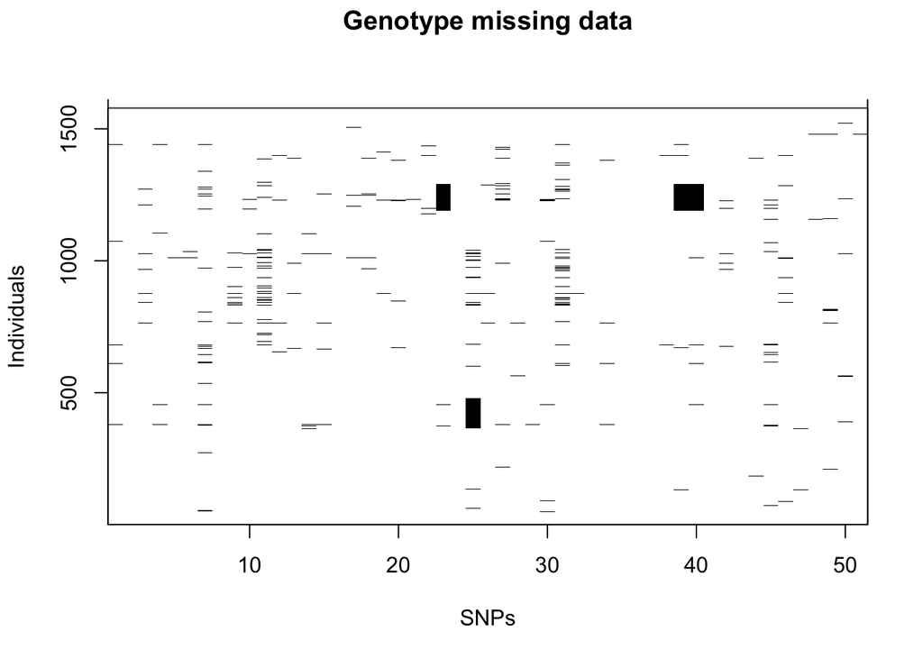

```r
 plotMissing(asthma.s, print.labels.SNPs = FALSE)
```

See which SNPs do not meet the Hardy-Weinberg equilibrium.

```r
hwe <- tableHWE(asthma.s, casecontrol)

# Divide by 51 as that's the number of SNPs we are analysing.
threshold <- 0.05 / 51
snpNHWE <- hwe[,2] < threshold
rownames(hwe)[snpNHWE]
```

```
## character(0)
```

```r
hwe[snpNHWE,]
```

```
##      all groups 0 1
```

All SNPs meet the HWE in the control group, so none of them need to be removed from the dataset before further analysis.

For a bit of fun, let’s find the SNP that is most outside the HWE.

```r
which.min(hwe[,3])
```

```
## rs184448
##       27
```

Perform an association analysis between rs184448 and the casecontrol.

```r
association(casecontrol ~ rs184448, data = asthma.s)
```

```
##
## SNP: rs184448  adjusted by:
##                 0    %   1    %   OR lower upper  p-value  AIC
## Codominant
## T/T           381 31.5  76 22.8 1.00             0.006777 1606
## T/G           624 51.5 189 56.8 1.52  1.13  2.04
## G/G           206 17.0  68 20.4 1.65  1.14  2.39
## Dominant
## T/T           381 31.5  76 22.8 1.00             0.001832 1604
## T/G-G/G       830 68.5 257 77.2 1.55  1.17  2.06
## Recessive
## T/T-T/G      1005 83.0 265 79.6 1.00             0.154665 1612
## G/G           206 17.0  68 20.4 1.25  0.92  1.70
## Overdominant
## T/T-G/G       587 48.5 144 43.2 1.00             0.090054 1611
## T/G           624 51.5 189 56.8 1.23  0.97  1.58
## log-Additive
## 0,1,2        1211 78.4 333 21.6 1.30  1.09  1.55 0.004112 1606
```

The dominant model is the most statistically significant, as individuals with this SNP seem to be 55% more likely to have asthma if they have this mutation.

```r
maxstat(asthma.s$casecontrol, asthma.s$rs184448)
```

```
##      dominant recessive log-additive MAX-statistic  Pr(>z)
## [1,]    9.710     2.026        8.253         9.710 0.00293 **
## ---
## Signif. codes:  0 '***' 0.001 '**' 0.01 '*' 0.05 '.' 0.1 ' ' 1
```

Control for a few variables to see how that affects the significance.

```r
association(casecontrol ~ rs184448 + gender + smoke + bmi, asthma.s)
```

```
##
## SNP: rs184448  adjusted by: gender smoke bmi
##                 0    %   1    %   OR lower upper   p-value  AIC
## Codominant
## T/T           379 31.5  72 22.4 1.00             0.0033366 1542
## T/G           620 51.5 183 57.0 1.56  1.15  2.12
## G/G           205 17.0  66 20.6 1.77  1.21  2.59
## Dominant
## T/T           379 31.5  72 22.4 1.00             0.0009985 1541
## T/G-G/G       825 68.5 249 77.6 1.61  1.20  2.16
## Recessive
## T/T-T/G       999 83.0 255 79.4 1.00             0.0907466 1549
## G/G           205 17.0  66 20.6 1.32  0.96  1.80
## Overdominant
## T/T-G/G       584 48.5 138 43.0 1.00             0.0999837 1549
## T/G           620 51.5 183 57.0 1.23  0.96  1.59
## log-Additive
## 0,1,2        1204 79.0 321 21.0 1.34  1.12  1.61 0.0016801 1542
```

The p-value has decreased and is now close to our threshold.

To further inspect the data, we can take a look at the association when smoking is modeled as a factor.

```r
association(casecontrol ~ dominant(rs184448)*factor(smoke), data=asthma.s)
```

```
##
##       SNP: dominant(rs184448  adjusted by:
##  Interaction
## ---------------------
##           0       OR lower upper   1      OR lower upper
## T/T     251  58 1.00    NA    NA 128 18 0.61  0.34  1.08
## T/G-G/G 570 194 1.47  1.06  2.05 256 62 1.05  0.70  1.56
##
## p interaction: 0.63789
##
##  factor(smoke) within dominant(rs184448
## ---------------------
## T/T
##     0  1   OR lower upper
## 0 251 58 1.00    NA    NA
## 1 128 18 0.61  0.34  1.08
##
## T/G-G/G
##     0   1   OR lower upper
## 0 570 194 1.00    NA    NA
## 1 256  62 0.71  0.52  0.98
##
## p trend: 0.63789
##
##  dominant(rs184448 within factor(smoke)
## ---------------------
## 0
##           0   1   OR lower upper
## T/T     251  58 1.00    NA    NA
## T/G-G/G 570 194 1.47  1.06  2.05
##
## 1
##           0  1   OR lower upper
## T/T     128 18 1.00    NA    NA
## T/G-G/G 256 62 1.72  0.98  3.03
##
## p trend: 0.63789
```

Expand the analysis to perform a whole genome association analysis using all of the SNPs.

```r
ans <- WGassociation(casecontrol, data=asthma.s)
head(ans)
```

|  | comments | codominant | dominant | recessive | overdominant | log-additive |
| --- | --- | --- | --- | --- | --- | --- |
| rs4490198 | NA | 0.5276539 | 0.2950324 | 0.9640036 | 0.29997808 | 0.4950632 |
| rs4849332 | NA | 0.9691216 | 0.9298560 | 0.8480614 | 0.82326907 | 0.9704917 |
| rs1367179 | NA | 0.6277476 | 0.5920450 | 0.3578625 | 0.86418642 | 0.4399397 |
| rs11123242 | NA | 0.6862212 | 0.6759556 | 0.3980084 | 0.92878230 | 0.5200937 |
| rs13014858 | NA | 0.5257794 | 0.2673926 | 0.8801133 | 0.34965529 | 0.4089684 |
| rs1430094 | NA | 0.1337513 | 0.1056947 | 0.5443219 | 0.04490279 | 0.3661074 |

Plot the results.

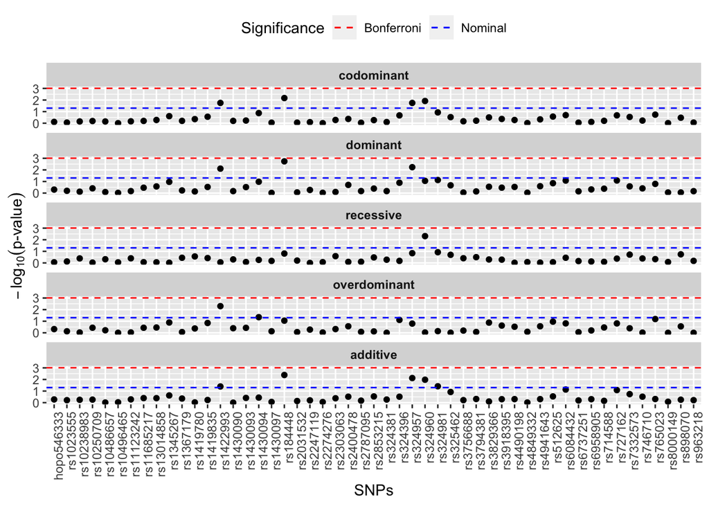

```r
plot(ans)
```

None of the SNPs meet our significance threshold.

```r
ans.max <- maxstat(asthma.s, casecontrol)
ans.max[,ans.max["Pr(>z)",] <= threshold]
```

```
##
## dominant
## recessive
## log-additive
## MAX-statistic
## Pr(>z)
```

## Haplotype Analysis

Perform a haplotype analysis to find sets of alleles that are associated with asthma.

```r
library(LDheatmap)
library(genetics)
library(biomaRt)
library(haplo.stats)
library(plyr)
```

Connect to the BioMart database to get the annotations for human SNPs.

```r
mart <- useMart("ENSEMBL_MART_SNP", dataset = "hsapiens_snp")
nrow(listFilters(mart))
```

```
## [1] 34
```

```r
head(listFilters(mart))
```

|  | name | description |
| --- | --- | --- |
| 1 | chr_name | Chromosome/scaffold name |
| 2 | start | Start |
| 3 | end | End |
| 4 | band_start | Band Start |
| 5 | band_end | Band End |
| 6 | marker_start | Marker Start |

Idenitfy the row that contains the annotations.

```r
listFilters(mart)[11,]
```

|  | name | description |
| --- | --- | --- |
| 11 | snp_filter | Filter by Variant mame (e.g. rs123, CM000001) |

Get the relevant attributes from the BioMart database.

```r
snps <- labels(asthma.s)
snpInfo <- getBM(
  c("refsnp_id", "chr_name", "chrom_start", "allele"),
  filters=c("snp_filter"),
  values=snps,
  mart=mart)

head(snpInfo)
```

|  | refsnp_id | chr_name | chrom_start | allele |
| --- | --- | --- | --- | --- |
| 1 | rs2247119 | 13 | 49513006 | T/C |
| 2 | rs2274276 | 13 | 49521817 | C/A/G |
| 3 | rs2031532 | 13 | 49506711 | A/C/G |
| 4 | rs3794381 | 13 | 49499427 | C/G |
| 5 | rs3829366 | 13 | 49529275 | T/A/C |
| 6 | rs4941643 | 13 | 49494251 | G/A/C/T |

Count the occurrences of each chromosome.

```r
count(snpInfo, "chr_name")
```

| chr_name | freq |
| --- | --- |
| 2 | 13 |
| 5 | 4 |
| 7 | 20 |
| 13 | 8 |
| 20 | 5 |

Find the min and max loci of the SNPs on chromosome 7.

```r
min(snpInfo[snpInfo$chr_name == 7,]$chrom_start)
```

```
## [1] 34653614
```

```r
max(snpInfo[snpInfo$chr_name == 7,]$chrom_start)
```

```
## [1] 34859961
```

Filter the snpInfo to the relevant data and set up the haplotype data.

```r
mask <- with(snpInfo, chr_name=="7" & chrom_start>34.6e6 & chrom_start<34.9e6)
snps.sel <- snpInfo[mask, "refsnp_id"]
sel <- which(names(asthma)%in%snps.sel)
asthma.hap <- setupSNP(asthma, sel, sep="")
```

Create a genotype object.

```r
snp.pos <- snpInfo[mask, "chrom_start"]
snp.geno <- data.frame(lapply(asthma.hap[, snps.sel], genotype))
```

Create an LD heatmap.

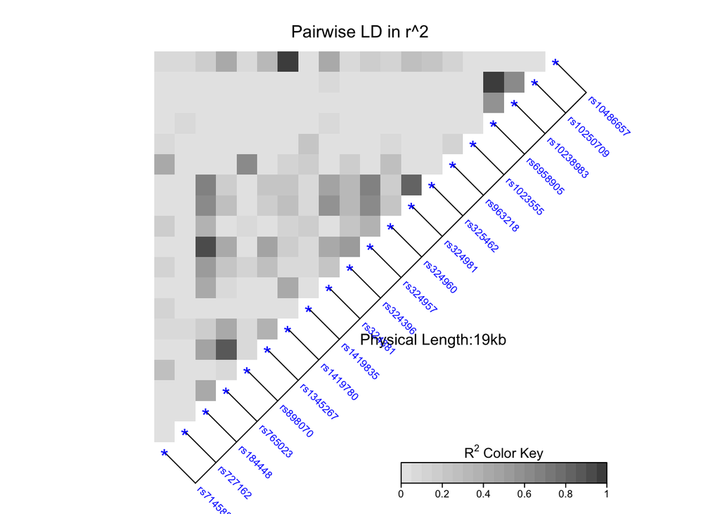

```r
LDheatmap(
  snp.geno,
  LDmeasure = "r",
  title = "Pairwise LD in r^2",
  add.map = TRUE,
  name = "myLDgrob",
  add.key = TRUE,
  SNP.name=snps.sel,
)
```

Select a set of neighbouring SNPs and compute their haplotype frequency.

```r
snpsH <- c("rs10486657", "rs10250709", "rs10238983", "rs6958905")
genoH <- make.geno(asthma.hap, snpsH)
em <- haplo.em(genoH, locus.label = snpsH, miss.val = c(0, NA))
em
```

```
## ================================================================================
##                                    Haplotypes
## ================================================================================
##    rs10486657 rs10250709 rs10238983 rs6958905 hap.freq
## 1           1          1          1         1  0.21703
## 2           1          1          2         1  0.10320
## 3           1          1          2         2  0.00032
## 4           1          2          1         2  0.00036
## 5           1          2          2         1  0.00582
## 6           1          2          2         2  0.48612
## 7           2          1          1         1  0.02577
## 8           2          1          2         1  0.00000
## 9           2          2          2         1  0.00119
## 10          2          2          2         2  0.16020
## ================================================================================
##                                     Details
## ================================================================================
## lnlike =  -3353.108
## lr stat for no LD =  4211.71 , df =  4 , p-val =  0
```

Haplotype 6 is the most probable, accumulating nearly 50% of the haplotype sample.

Measure the association between any of the haplotypes and an individual having asthma using a GLM.

```r
trait <- asthma.hap$casecontrol
mod <- haplo.glm(
  trait ~ genoH,
  family="binomial",
  locus.label=snpsH,
  allele.lev=attributes(genoH)$unique.alleles,
  control = haplo.glm.control(haplo.freq.min=0.05)
)
intervals(mod)
```

```
##                freq   or   95%   C.I.   P-val
##         CGTT 0.4861   1.00 Reference haplotype
##         CACC 0.2170   1.04 (   0.82 -   1.32 )  0.7287
##         CATC 0.1032   0.77 (   0.57 -   1.05 )  0.1045
##         TGTT 0.1602   1.00 (   0.77 -   1.30 )  0.9915
##   genoH.rare 0.0335   0.86 (   0.46 -   1.59 )  0.6224
```

None of the haplotypes are significantly associated with asthma.

Rather than selecting four SNPs like above, we can use a sliding window for better haplotype inference. We’ll use a window size between 3 and 6.

```r
snpsH2 <- colnames(snp.geno)
genoH2 <- make.geno(asthma.hap, snpsH2)
trait <- asthma.hap$casecontrol
haplo.score <- list()

for (i in 3:6) {
  haplo.score[[i-2]] <- haplo.score.slide(
    trait,
    genoH2,
    trait.type="binomial",
    n.slide=i,
    simulate=TRUE,
    sim.control=score.sim.control(min.sim=100, max.sim=200)
  )
}
```

Plot the results.

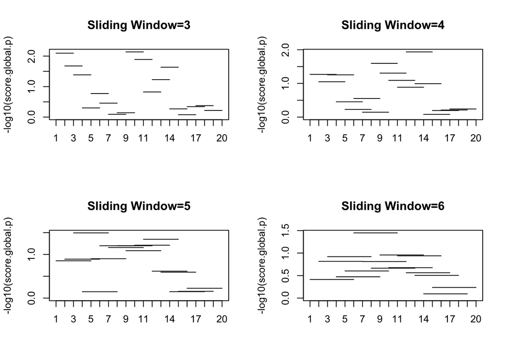

```r
par(mfrow=c(2,2))

for (i in 3:6) {
  plot(haplo.score[[i-2]])
  title(paste("Sliding Window=", i, sep=""))
}
```

The highest -log10 p-value is obtained for a haplotype of 3 SNP length starting at the 9th SNP of the selected SNPs. Let’s create another GLM using this haplotype to see if we can find a statistically significant association with asthma.

```r
snpsH3 <- snpsH2[9:11]
genoH3 <- make.geno(asthma.hap, snpsH3)
mod <- haplo.glm(
  trait~genoH3,
  family="binomial",
  locus.label=snpsH3,
  allele.lev=attributes(genoH3)$unique.alleles,
  control = haplo.glm.control(haplo.freq.min=0.05)
)

intervals(mod)
```

```
##                freq   or   95%   C.I.   P-val
##          ACG 0.3536   1.00 Reference haplotype
##          GCA 0.1476   1.35 (   1.04 -   1.77 )  0.0250
##          GCG 0.2102   0.85 (   0.65 -   1.11 )  0.2314
##          GTA 0.2822   1.12 (   0.90 -   1.40 )  0.3186
##  genoH3.rare 0.0064   2.83 (   0.99 -   8.14 )  0.0532
```

We see that individuals carrying the haplotype GCA have a 35% increased risk of asthma relative to those having the reference haplotype ACG.

```r
lrt <- mod$lrt
pchisq(lrt$lrt, lrt$df, lower=FALSE)
```

```
## [1] 0.008544227
```

The low chi-squared value suggests that this difference is significant.

## Genetric Score

Create a polygenic risk score to assess the collective prediction of the phenotype risk associated with multiple SNPs.

```r
library(PredictABEL)
```

Identify which columns in the dataset contains SNPs and measure their association with asthma using a whole genome association analysis.

```r
dd.s <- setupSNP(asthma, 7:ncol(asthma), sep="")
ans <- WGassociation(casecontrol, dd.s, model="log-additive")
```

Filter the SNPs so that only those that show an association at 0.1 level are included in the model.

```r
sel <- labels(dd.s)[additive(ans) < 0.1]
dd.sel <- dd.s[,sel]
head(dd.sel)
```

|  | rs1422993 | rs184448 | rs324957 | rs324960 | rs324981 | rs727162 | rs6084432 |
| --- | --- | --- | --- | --- | --- | --- | --- |
| 1 | G/G | T/T | G/G | C/T | A/T | G/G | G/G |
| 2 | G/T | G/G | A/A | C/C | A/A | G/G | G/G |
| 3 | G/G | T/T | G/G | C/T | T/T | G/C | G/A |
| 4 | G/T | T/G | G/A | C/C | A/T | G/G | G/G |
| 5 | G/T | T/T | G/G | C/C | A/T | G/G | G/G |
| 6 | G/G | T/T | G/G | C/T | A/T | G/C | G/G |

Reformat the SNP genotypes as 0, 1, and 2 using additive so that they can be used as a feature in the model. Join the case/control variables and the reformatted SNP genotypes.

```r
dd.sel <- data.frame(lapply(dd.sel, additive))
dd.end <- data.frame(casecontrol=dd.s$casecontrol, dd.sel)
head(dd.end)
```

|  | casecontrol | rs1422993 | rs184448 | rs324957 | rs324960 | rs324981 | rs727162 | rs6084432 |
| --- | --- | --- | --- | --- | --- | --- | --- | --- |
| 1 | 0 | 0 | 0 | 0 | 1 | 1 | 0 | 0 |
| 2 | 0 | 1 | 2 | 2 | 0 | 0 | 0 | 0 |
| 3 | 0 | 0 | 0 | 0 | 1 | 2 | 1 | 1 |
| 4 | 0 | 1 | 1 | 1 | 0 | 1 | 0 | 0 |
| 5 | 1 | 1 | 0 | 0 | 0 | 1 | 0 | 0 |
| 6 | 0 | 0 | 0 | 0 | 1 | 1 | 1 | 0 |

First remove SNP genotypes with missing values, as they are not supported by the model. Then perform a stepwise model selection to determine which SNPs best predict asthma status.

```r
dd.end.complete <- dd.end[complete.cases(dd.end),]
mod <- stepAIC(
  glm(casecontrol ~ ., dd.end.complete, family="binomial"),
  method="forward",
  trace=0
)

snps.score <- names(coef(mod))[-1]
snps.score
```

```
## [1] "rs1422993" "rs324957"  "rs727162"  "rs6084432"
```

Collectively, these are the most predictive SNPs. They will be used to create the genetic score. But first, let’s take a look at a summary that shows the SNPs’ associations of the selected SNPs with asthma.

```r
summary(mod)
```

```
##
## Call:
## glm(formula = casecontrol ~ rs1422993 + rs324957 + rs727162 +
##     rs6084432, family = "binomial", data = dd.end.complete)
##
## Deviance Residuals:
##     Min       1Q   Median       3Q      Max
## -0.9775  -0.7290  -0.6655  -0.5596   1.9655
##
## Coefficients:
##             Estimate Std. Error z value Pr(>|z|)
## (Intercept) -1.77498    0.13635 -13.018  < 2e-16 ***
## rs1422993    0.20528    0.09849   2.084  0.03714 *
## rs324957     0.25937    0.09266   2.799  0.00512 **
## rs727162     0.18037    0.10447   1.727  0.08424 .
## rs6084432    0.19982    0.11388   1.755  0.07932 .
## ---
## Signif. codes:  0 '***' 0.001 '**' 0.01 '*' 0.05 '.' 0.1 ' ' 1
##
## (Dispersion parameter for binomial family taken to be 1)
##
##     Null deviance: 1587.0  on 1517  degrees of freedom
## Residual deviance: 1569.2  on 1513  degrees of freedom
## AIC: 1579.2
##
## Number of Fisher Scoring iterations: 4
```

Identify the columns of the SNPs that will be used to compute the genetic score.

```r
pos <- which(names(dd.end.complete)%in%snps.score)
pos
```

```
## [1] 2 4 7 8
```

Create the scores using riskScore.

```r
score <- riskScore(
  mod,
  data=dd.end.complete,
  cGenPreds=pos,
  Type="unweighted"
)
table(score)
```

```
## score
##   0   1   2   3   4   5   6
## 101 389 491 347 139  44   7
```

Plot the distribution of the risk scores.

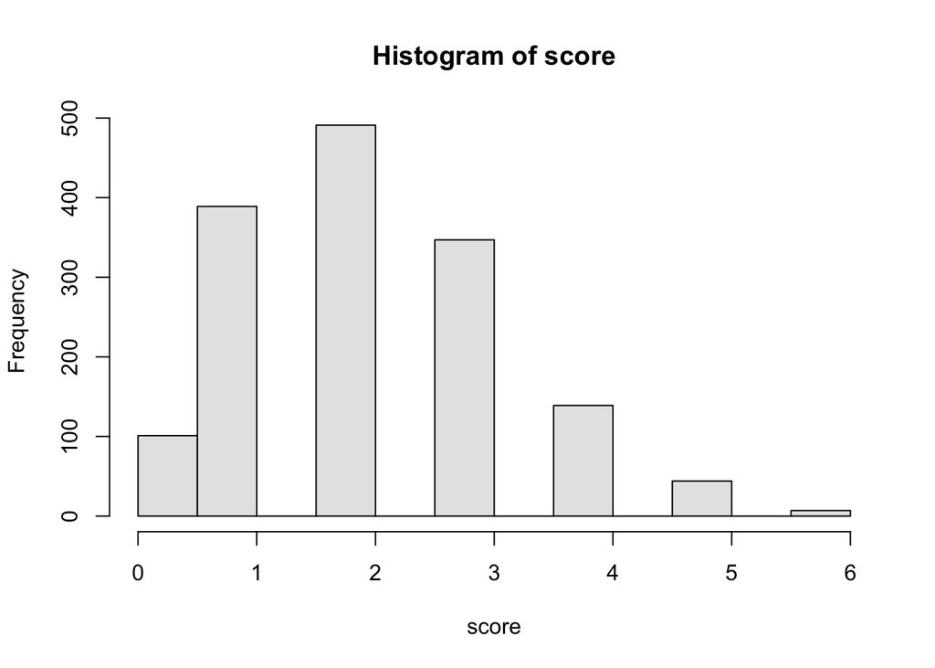

```r
hist(score, col="gray90")
```

Test the association between the genetic score and asthma status using a generalised linear model.

```r
mod.lin <- glm(casecontrol~score, dd.end.complete, family="binomial")
exp(coef(mod.lin)[2])
```

```
##    score
## 1.240039
```

Plot the model’s performance.

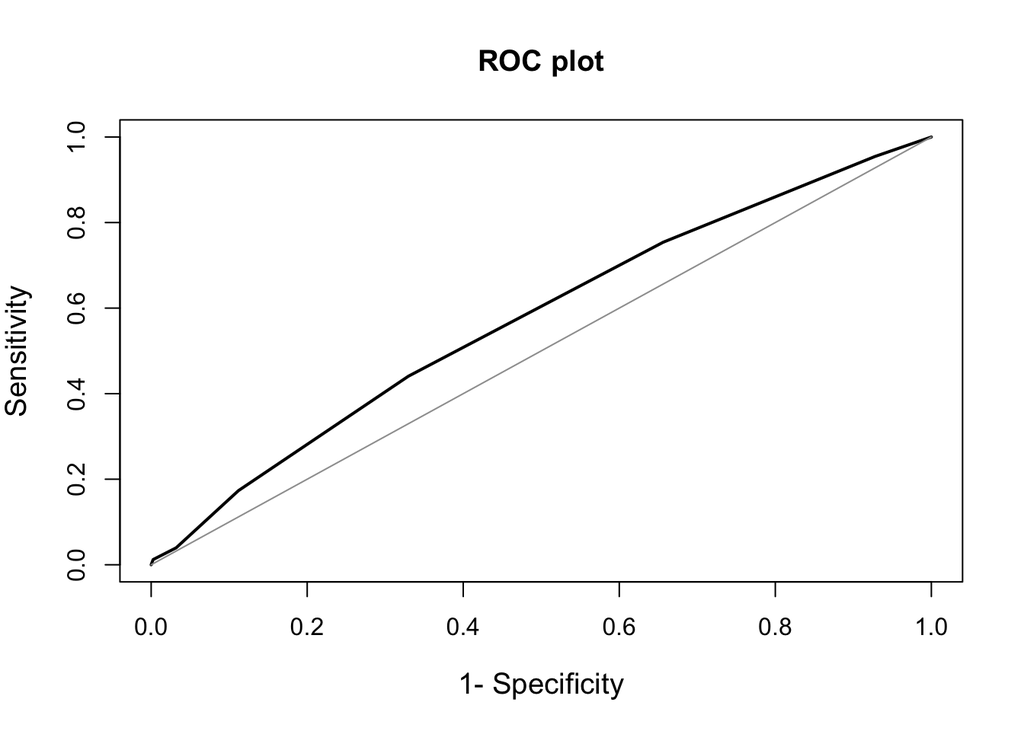

```
## AUC [95% CI] for the model 1 :  0.574 [ 0.54  -  0.607 ]
```

```r
predrisk <- predRisk(mod.lin, dd.end.complete)
plotROC(data=dd.end.complete, cOutcome=1, predrisk = predrisk)
```